# When Noise Restores Uniqueness

Differential Equations Under Stochastic Perturbations

Carlos Saúl Rivera Landeros

Facultad de Ciencias, UNAM

## Differential equations

Let us consider the ordinary differential equation

$${\color[RGB]{24, 84, 191}
\text{d}X(t) = f(t,X(t))\,\text{d}t,\quad 0\leq t\leq T,
}$$

where
$$f:[0,T]\times\mathbb{R}^d\to\mathbb{R}^d\quad\text{and}\quad X:[0,T]\to\mathbb{R}^d,$$
and $d\geq 1$ is an integer that represents the dimension.

Three questions immediately arise.

## Differential equations

Let us consider the ordinary differential equation

$${\color[RGB]{24, 84, 191}
\text{d}X(t) = f(t,X(t))\,\text{d}t,\quad 0\leq t\leq T,
}$$

- how do we interpret the equation,
- what does it mean to be a solution,
- what do we understand by uniqueness.

## Uniqueness of solutions

Let us consider the ordinary differential equation

$$X'(t)= f(t,X(t)),\quad X(0)= x_0.$$

- Cauchy-Lispchitz theorem ($\leq$ 1821, 1868)
  $${\color[RGB]{194,65,12}
  \left|f(t,x)-f(t,y)\right|\leq L\,\left|x-y\right|
  }$$
- Osgood’s theorem (1898)
  $${\color[RGB]{194,65,12}
  \left|f(t,x)-f(t,y)\right|\leq g(\left|x-y\right|),\quad \int_0^1 \frac{1}{g(z)}\,\text{d}z = \infty
  }$$

## Uniqueness fails: multiple solutions

Consider the field
$$f(t,x) := 2\,\text{sgn}(x)\,\sqrt{|x|}$$
and the associated ordinary differential equation

$$\begin{cases}
\begin{aligned}
X'(t) &= f(t,X(t)), \quad 0\leq t\leq T, \\
X(0) &= x_0\in\mathbb{R}.
\end{aligned}
\end{cases}$$

Do solutions exist? Are they unique?

[figure not shown]

## Solutions of the equation

[figure not shown]

## Solutions of the equation

[figure not shown]

## Solutions of the equation

[figure not shown]

## Peano’s paintbrush

[figure not shown]

## Interpretation of the equation

If $f:[0,T]\times\mathbb{R}^d\to\mathbb{R}^d$ is Borel-measurable and bounded the problem might be interpreted as
$$X(t) = x_0 + \int_0^t f(s,X(s))\,\text{d} s,\quad0\leq t\leq T.$$

We have even more problems!

$${\color[RGB]{194,65,12}
f(t,x)=\begin{cases}
\begin{aligned}
-1 &\quad\text{si }x\geq 0 \\
1 &\quad\text{si }x < 0.
\end{aligned}
\end{cases}
}$$
When $x_0=0$ there is no solution

[figure not shown]

## Stochastic noise

$$X(t) = x_0 + \int_0^t f(s,X(s))\,\text{d} s.$$

$X$ functions as a model for the evolution of some system.

We would expect the evolution to be determined by the equation.

## Stochastic noise

$$X(t) = x_0 + \int_0^t f(s,X(s))\,\text{d} s.$$

We can add a random external perturbation:
$$X_t = x_0 + \int_0^t f(s,X_s)\,\text{d}s + {\color[RGB]{128,0,153}\varepsilon B_t}.$$
${\color[RGB]{128,0,153}B = (B_t)_{t\in[0,T]}}$ is a $d$-dimensional Brownian motion;

${\color[RGB]{128,0,153}\varepsilon>0}$ controls the intensity of the noise.

## Brownian motion

[figure not shown]

${\color[RGB]{128,0,153}B=(B_t)_{t\in[0,T]}}$ is a $1$-dimensional Brownian motion if

- $B_0=0$ and $B$ has idependent increments,
- $B_t-B_s=N(0,t-s)$ for $0\leq s\leq t\leq T$,
- $B$ has continuous paths.

## Stochastic differential equations

Let $(\Omega,\mathscr{F},(\mathscr{F}_t),P)$ be a filtered probability space and $B$ an $(\mathscr{F}_t)$-Brownian motion.

- $B_t$ is $\mathscr{F}_t$-measurable for each $0\leq t\leq T$,
- $B_t-B_s$ is independent of $\mathscr{F}_s$, $0\leq s\leq t\leq T$.

A continuous adapted process $X$ is a solution when
$$X_t = x_0 + \int_0^t f(s,X_s)\,\text{d}s + {\color[RGB]{128,0,153}\varepsilon B_t}, \quad 0\leq t\leq T,\quad\text{a. s.}$$

## Uniqueness for stochastic equations

$$X_t = x_0 + \int_0^t f(s,X_s)\,\text{d}s + {\color[RGB]{128,0,153}\varepsilon\,B_t}, \quad 0\leq t\leq T,$$

### Uniqueness in law

We have uniqueness in law if, for each $x_0\in\mathbb{R}^d$, any two solutions of the problem have the same distribution in $\mathcal{C}([0,T];\mathbb{R}^d)$.

### Pathwise uniqueness

We have pathwise uniqueness if, when fixing a filtration $(\mathscr{F}_t)$, a Brownian motion ${\color[RGB]{128,0,153}B}$ and $x_0\in\mathbb{R}^d$, any two solutions $X^{(1)}$ and $X^{(2)}$ satisfy that $X^{(1)}_t=X^{(2)}_t$ a. s.

## What happens with each path?

For a fixed Brownian path ${\color[RGB]{128,0,153}B=B(\omega)}$, to seek a continuous $X$ such that
$$X(t) = x_0 + \int_0^t f(s,X(s))\,\text{d} s + {\color[RGB]{128,0,153}\varepsilon B_t(\omega)},\quad 0\leq t\leq T,$$
does make sense.

Do solutions exist? Are they unique?

## Davie’s uniqueness theorem (2007)

Given a Borel-measurable bounded function $f:[0,T]\times\mathbb{R}^d\to\mathbb{R}^d$, for almost every Brownian path $B=B(\omega)$, the equation
$$X(t) = x_0 + \int_0^t f(s,X(s))\,\text{d} s +{\color[RGB]{128, 0, 153}\varepsilon\,B_t},\quad 0\leq t\leq T,$$
has exactly one continuous solution.

No measurability or adaptability hypothesis on the collection $(X(\omega))_{\omega\in\Omega}$ is required beforehand.

## Path-by-path uniqueness

$$X(t) = x_0 + \int_0^t f(s,X(s))\,\text{d} s + {\color[RGB]{128, 0, 153}\varepsilon\,B_t},\quad 0\leq t\leq T.$$

## Path-by-path uniqueness

$$X(t) = x_0 + \int_0^t f(s,X(s))\,\text{d} s + {\color[RGB]{26, 145, 34}\gamma(t)},\quad 0\leq t\leq T.$$

- ${\color[RGB]{26, 145, 34}\gamma:[0,T]\to\mathbb{R}^d}$ is a continuous function.
1. Find analytical properties for ${\color[RGB]{26, 145, 34}\gamma}$ that guarantee the perturbed equation admits only one solution.
2. Show that such properties are satisfied by a typical realization of the noise $B(\omega)$ under consideration.

## Path-by-path uniqueness

$$X(t) = x_0 + \int_0^t f(s,X(s))\,\text{d} s + {\color[RGB]{26, 145, 34}\gamma(t)},\quad 0\leq t\leq T.$$

Davie’s result tells us that, if $f\in L^{\infty}$, the equation is regularized for all ${\color[RGB]{26, 145, 34}\gamma}\in\Omega_0\subseteq\mathcal{C}([0,T];\mathbb{R}^d)$, where $\Omega_0$ is an event of Wiener measure $1$.

This is known as path-by-path uniqueness.

## Random vector field

$$X(t) = x_0 + \int_0^t f(s,X(s))\,\text{d} s + {\color[RGB]{128,0,153}\varepsilon B_t(\omega)}.$$

Making the change of variable ${\color[RGB]{128,0,153}U}=X-{\color[RGB]{128,0,153}\varepsilon B}$ we get
$${\color[RGB]{128, 0, 153}U(t) = x_0 + \int_0^t f(s,\varepsilon\,B_s+U(s))\,\text{d} s.}$$

The vector field that defines this equation is random.

$$f(t,x)\mapsto f(t,{\color[RGB]{128,0,153}\varepsilon B_t}+x) \quad\text{for } {\color[RGB]{128,0,153}\varepsilon}>0.$$

## A look at the solutions

[figure not shown]

$$f(t,x) = Ax,\quad A\in\mathbb{R}^{2\times 2},$$

$U(t) = x_0+\int_0^t f(s,U(s))\,\text{d}s$

## A look at the solutions

[figure not shown]

$$f(t,x) = Ax,\quad A\in\mathbb{R}^{2\times 2},$$

$U(t) = x_0+\int_0^t f(s,\varepsilon\,B_s+U(s))\,\text{d}s$

$$f(t,x) \mapsto f(t,\varepsilon\,B_s+x)$$

## A look at the solutions

[figure not shown]

$$f(t,x) = Ax,\quad A\in\mathbb{R}^{2\times 2},$$

$U(t) = x_0+\int_0^t f(s,\varepsilon\,B_s+U(s))\,\text{d}s$

$$f(t,x) \mapsto f(t,\varepsilon\,B_s+x)$$

## A look at the solutions

[figure not shown]

$$f(t,x) = Ax,\quad A\in\mathbb{R}^{2\times 2},$$

$X(t) = x_0+\int_0^t f(s,X(s))\,\text{d}s$

## A look at the solutions

[figure not shown]

$$f(t,x) = Ax,\quad A\in\mathbb{R}^{2\times 2},$$

$X(t) = x_0+\int_0^t f(s,X(s))\,\text{d}s+\varepsilon\,B_t$

$$U=X-\varepsilon\,B$$

## A look at the solutions

[figure not shown]

$$f(t,x) = Ax,\quad A\in\mathbb{R}^{2\times 2},$$

$X(t) = x_0+\int_0^t f(s,X(s))\,\text{d}s+\varepsilon\,B_t$

$$U=X-\varepsilon\,B$$

## Occupation measure

Let $\gamma:[0,T]\to\mathbb{R}^d$ be a continuous curve. Define its occupation measure by
$${\color[RGB]{24, 84, 191}
\mu_{T,\gamma}(A) := \int_0^T 1_{A}(\gamma(t))\,\text{d}t},\quad A\in\mathscr{B}(\mathbb{R}^{d}).$$

Intuitively $\mu_{T,\gamma}(A)$ measures how much time the curve $\gamma$ stays in $A$. If $\varphi:\mathbb{R}^{d}\to\mathbb{R}$ is bounded

$$\mu_{T,\gamma}(\varphi) := \int_0^T \varphi(\gamma(t))\,\text{d}t = \int\varphi(z)\,\mu_{T,\gamma}(\text{d}z).$$

## Occupation measure

Let $\gamma:[0,T]\to\mathbb{R}^d$ be a continuous curve

[figure not shown]

$$\mu_{T,\gamma}(A) = t_2-t_1$$

## The case of a brownian path

Let $\gamma(t):= x+B_t$ for each $t\in [0,T]$, with $B=B(\omega)$ a Brownian path.

[figure not shown]

## Lipschitz property in the average

There exists a constant $C=C(d)>0$ such that,

- if $\varphi\in L^{\infty}(\mathbb{R}^d)$, with $\lVert \varphi\rVert_{\infty}\leq 1$,
- $p\geq 2$ is even,

$$\mathbb{E}\!\left[\left|\mu_{T,x+B}(\varphi)-\mu_{T,y+B}(\varphi)\right|^p\right]\leq C^p\,T^{p/2}\,(p/2)!\,\left|x-y\right|^p$$

for every $x,y\in\mathbb{R}^d$

## Continuity of the occupation measure

For almost all Brownian paths $B=B(\omega)$ the vector field
$$x\in\mathbb{R}^d\mapsto\mu_{T,x+B}(\varphi)=\int_0^T \varphi(x+B_t)\,\text{d}t$$

is locally $\alpha$-Hölder continuous for every $\alpha<1$.

$$\left|\mu_{T,x+B}(\varphi)-\mu_{T,y+B}(\varphi)\right|\leq C\left| x-y\right|^{\alpha}$$

## Continuity of the occupation measure

[figure not shown]

$\left|\mu_{1,x}(\varphi) - \mu_{1,y}(\varphi)\right|=2\quad \left|\mu_{1,x+B}(\varphi) - \mu_{1,y+B}(\varphi)\right|\ll 1$

## What if the noise goes to zero?

Let $f(t,x) := 2\,\text{sgn}(x)\,\sqrt{|x|}$ and let $X_{\varepsilon}$ be the solution of

$$X_{\varepsilon}(t) = \int_0^t f(s,X_{\varepsilon}(s))\,\text{d} s + \varepsilon B_t,\quad 0\leq t\leq T.$$
Denote by $P_{\varepsilon}$ its distribution in $\mathcal{C}([0,T];\mathbb{R})$.

- The family $(P_\varepsilon)_{\varepsilon>0}$ is tense.

Every sequence in this family has a subsequence that converges weakly to some measure $\mu$ in $\mathcal{C}([0,T];\mathbb{R})$

## What if the noise goes to zero?

Let $f(t,x) := 2\,\text{sgn}(x)\,\sqrt{|x|}$ and let $X_{\varepsilon}$ be the solution of

$$X_{\varepsilon}(t) = \int_0^t f(s,X_{\varepsilon}(s))\,\text{d} s + \varepsilon B_t,\quad 0\leq t\leq T.$$
Denote by $P_{\varepsilon}$ its distribution in $\mathcal{C}([0,T];\mathbb{R})$.

- The family $(P_\varepsilon)_{\varepsilon>0}$ is tense.

Measures obtained in this way are carried by the set of solutions to the deterministic equation
$$X'(t) = f(t,X(t)), \quad X(0)=0.$$

## Zero-noise selection

Bafico and Baldi (1981) proved that the whole family
$$(P_\varepsilon)_{\varepsilon>0}$$
converges weakly to a probability measure $P$ in $\mathcal{C}([0,T];\mathbb{R})$ carried by $\{X^{(+)},X^{(-)}\}$.

[figure not shown]

$P=\frac{1}{2}\,\delta_{X^{(+)}}+ \frac{1}{2}\,\delta_{X^{(-)}}$
$$X^{(+)}(t)=t^2,\quad X^{(-)}(t)=-t^2,$$

## What happens with each path?

[figure not shown]

## Noise in fluid dynamics

Navier-Stokes equations:
$$\begin{cases}
\begin{aligned}
\frac{\partial u}{\partial t}+(u\cdot\nabla)\,u-\nu\,\Delta u + \nabla p &= f\quad\text{in }[0,T]\times\mathbb{R}^d,\\
\text{div}\,u &=0\quad\text{in }[0,T]\times\mathbb{R}^d.
\end{aligned}
\end{cases}$$

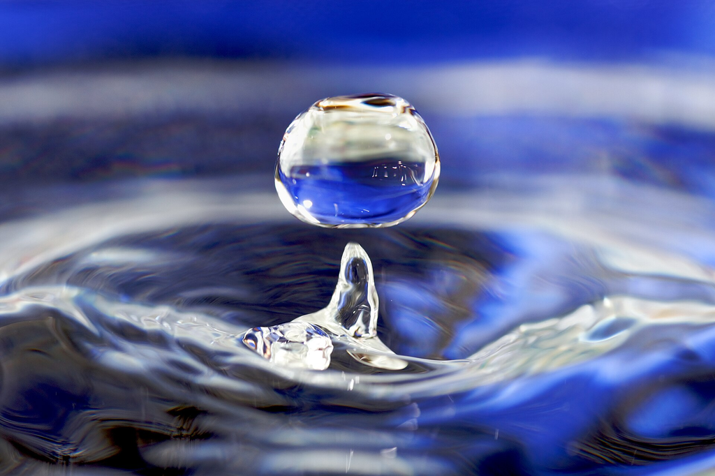

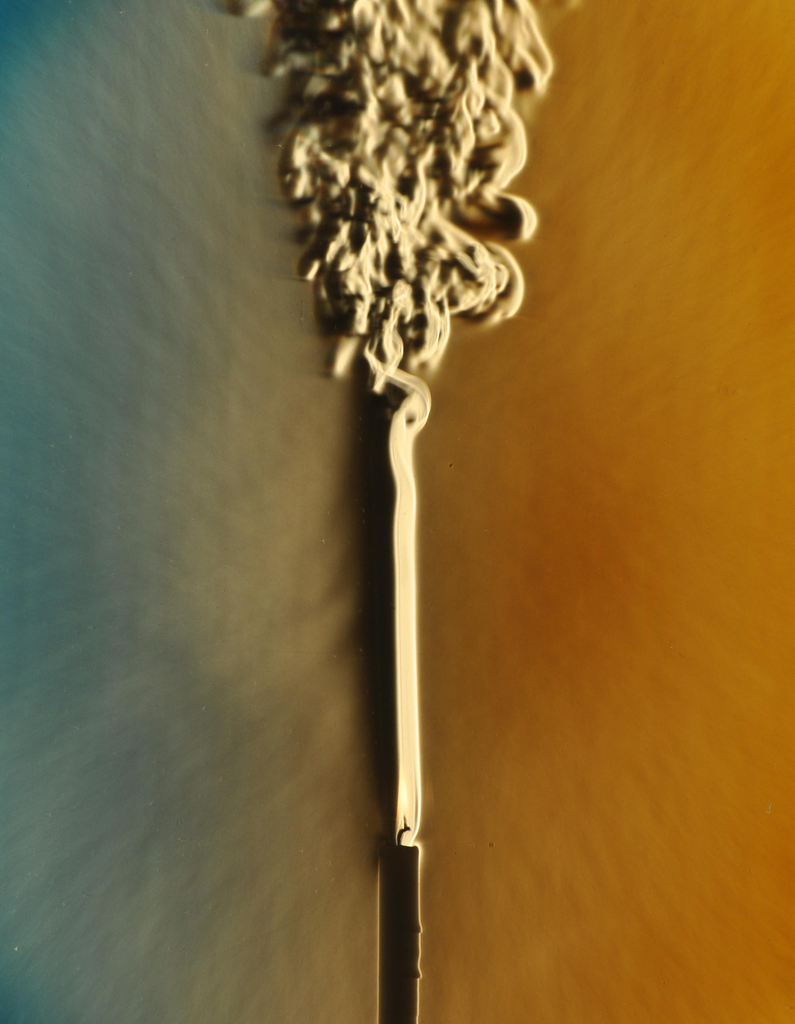